# HW3 - EDAV - Mitras

Mitras Dimitrios

2023-11-19

# Part A

**The present study concerns a dataset of medical measurements. Specifically, it contains 403 records for 22 variables, of which 7 are calculated from other variables. The data concerns measurements related to diabetes.

For the first part of the study, the handling of potential outliers and the analysis/visualization of the data were requested in order to understand the dataset.

For the completion of the assignment, pre-existing code from lectures, the internet, and AI-generated models (ChatGPT, Bard) was utilized.**

## Understanding the Dataset

**First, read the data and load the libraries**

```r
library(ggplot2)
library(tidyverse)
library(reshape2)

df <- read.csv("diabetes.csv")
head(df)
```

```
##     id total_cholesterol stabilized.glucose hdl total_chol_hdl_ratio
## 1 1000               203                 82  56                  3.6
## 2 1001               165                 97  24                  6.9
## 3 1002               228                 92  37                  6.2
## 4 1003                78                 93  12                  6.5
## 5 1005               249                 90  28                  8.9
## 6 1008               248                 94  69                  3.6
##   glycosoloatedhgb   location age gender height weight bp.1s bp.1d waist hip
## 1             4.31 Buckingham  46      1     62    121   118    59    29  38
## 2             4.44 Buckingham  29      1     64    218   112    68    46  48
## 3             4.64 Buckingham  58      1     61    256   190    92    49  57
## 4             4.63 Buckingham  67      0     67    119   110    50    33  38
## 5             7.72 Buckingham  64      0     68    183   138    80    44  41
## 6             4.81 Buckingham  34      0     71    190   132    86    36  42
##   diabetes_diagnosis      BMI waist_hip_ratio BMI_cat_5 age_cat waist_hip_cat
## 1                  0 22.12877       0.7631579         1       2             0
## 2                  0 37.41553       0.9583333         4       1             1
## 3                  0 48.36549       0.8596491         5       3             1
## 4                  0 18.63600       0.8684211         1       4             0
## 5                  1 27.82202       1.0731707         2       3             1
## 6                  0 26.49673       0.8571429         2       1             0
##   BMI_cat_3
## 1         1
## 2         3
## 3         3
## 4         1
## 5         2
## 6         2
```

**General data overview and missing value checks**

```r
summary(df)
```

```
##        id        total_cholesterol stabilized.glucose      hdl
##  Min.   : 1000   Min.   : 78.0     Min.   : 48.0      Min.   : 12.00
##  1st Qu.: 4792   1st Qu.:179.0     1st Qu.: 81.0      1st Qu.: 38.00
##  Median :15766   Median :204.0     Median : 89.0      Median : 46.00
##  Mean   :15978   Mean   :207.8     Mean   :106.7      Mean   : 50.45
##  3rd Qu.:20336   3rd Qu.:230.0     3rd Qu.:106.0      3rd Qu.: 59.00
##  Max.   :41756   Max.   :443.0     Max.   :385.0      Max.   :120.00
##                  NA's   :1                            NA's   :1
##  total_chol_hdl_ratio glycosoloatedhgb   location              age
##  Min.   : 1.500       Min.   : 2.68    Length:403         Min.   :19.00
##  1st Qu.: 3.200       1st Qu.: 4.38    Class :character   1st Qu.:34.00
##  Median : 4.200       Median : 4.84    Mode  :character   Median :45.00
##  Mean   : 4.522       Mean   : 5.59                       Mean   :46.85
##  3rd Qu.: 5.400       3rd Qu.: 5.60                       3rd Qu.:60.00
##  Max.   :19.300       Max.   :16.11                       Max.   :92.00
##  NA's   :1            NA's   :13
##      gender           height          weight          bp.1s
##  Min.   :0.0000   Min.   :52.00   Min.   : 99.0   Min.   : 90.0
##  1st Qu.:0.0000   1st Qu.:63.00   1st Qu.:151.0   1st Qu.:121.5
##  Median :1.0000   Median :66.00   Median :172.5   Median :136.0
##  Mean   :0.5806   Mean   :66.02   Mean   :177.6   Mean   :136.9
##  3rd Qu.:1.0000   3rd Qu.:69.00   3rd Qu.:200.0   3rd Qu.:146.5
##  Max.   :1.0000   Max.   :76.00   Max.   :325.0   Max.   :250.0
##                   NA's   :5       NA's   :1
##      bp.1d            waist            hip        diabetes_diagnosis
##  Min.   : 48.00   Min.   :26.00   Min.   :30.00   Min.   :0.0000
##  1st Qu.: 75.00   1st Qu.:33.00   1st Qu.:39.00   1st Qu.:0.0000
##  Median : 82.00   Median :37.00   Median :42.00   Median :0.0000
##  Mean   : 83.37   Mean   :37.89   Mean   :43.05   Mean   :0.1538
##  3rd Qu.: 91.00   3rd Qu.:41.00   3rd Qu.:46.00   3rd Qu.:0.0000
##  Max.   :124.00   Max.   :56.00   Max.   :64.00   Max.   :1.0000
##                                                   NA's   :13
##       BMI        waist_hip_ratio    BMI_cat_5        age_cat
##  Min.   :15.20   Min.   :0.6818   Min.   :1.000   Min.   :1.00
##  1st Qu.:24.13   1st Qu.:0.8295   1st Qu.:1.000   1st Qu.:1.00
##  Median :27.80   Median :0.8788   Median :2.000   Median :2.00
##  Mean   :28.78   Mean   :0.8805   Mean   :2.299   Mean   :2.33
##  3rd Qu.:32.24   3rd Qu.:0.9250   3rd Qu.:3.000   3rd Qu.:3.00
##  Max.   :55.78   Max.   :1.1429   Max.   :5.000   Max.   :4.00
##  NA's   :6                        NA's   :12
##  waist_hip_cat     BMI_cat_3
##  Min.   :0.000   Min.   :1.000
##  1st Qu.:0.000   1st Qu.:1.000
##  Median :1.000   Median :2.000
##  Mean   :0.737   Mean   :2.069
##  3rd Qu.:1.000   3rd Qu.:3.000
##  Max.   :1.000   Max.   :3.000
##  NA's   :19      NA's   :12
```

```r
print(colSums(is.na(df)))
```

```
##                   id    total_cholesterol   stabilized.glucose
##                    0                    1                    0
##                  hdl total_chol_hdl_ratio     glycosoloatedhgb
##                    1                    1                   13
##             location                  age               gender
##                    0                    0                    0
##               height               weight                bp.1s
##                    5                    1                    0
##                bp.1d                waist                  hip
##                    0                    0                    0
##   diabetes_diagnosis                  BMI      waist_hip_ratio
##                   13                    6                    0
##            BMI_cat_5              age_cat        waist_hip_cat
##                   12                    0                   19
##            BMI_cat_3
##                   12
```

There are some NAs, but their number is not too high. We will not process the missing values initially.

Lets take a look at our data Let’s start by displaying the formula for the variables and some plots to better understand them.

- numeric: “total_cholesterol” “stabilized.glucose” “hdl” “total_chol_hdl_ratio” “glycosoloatedhgb” “height” “bp.1s” “bp.1d” “waist” “hip”  
  “weight” “age” “BMI” “waist_hip_ratio” (
- binary: “gender” “diabetes_diagnosis” “location”
- categorical: “BMI_cat_5” “age_cat” “waist_hip_cat” “BMI_cat_3”

**Histogram of Total Cholesterol**

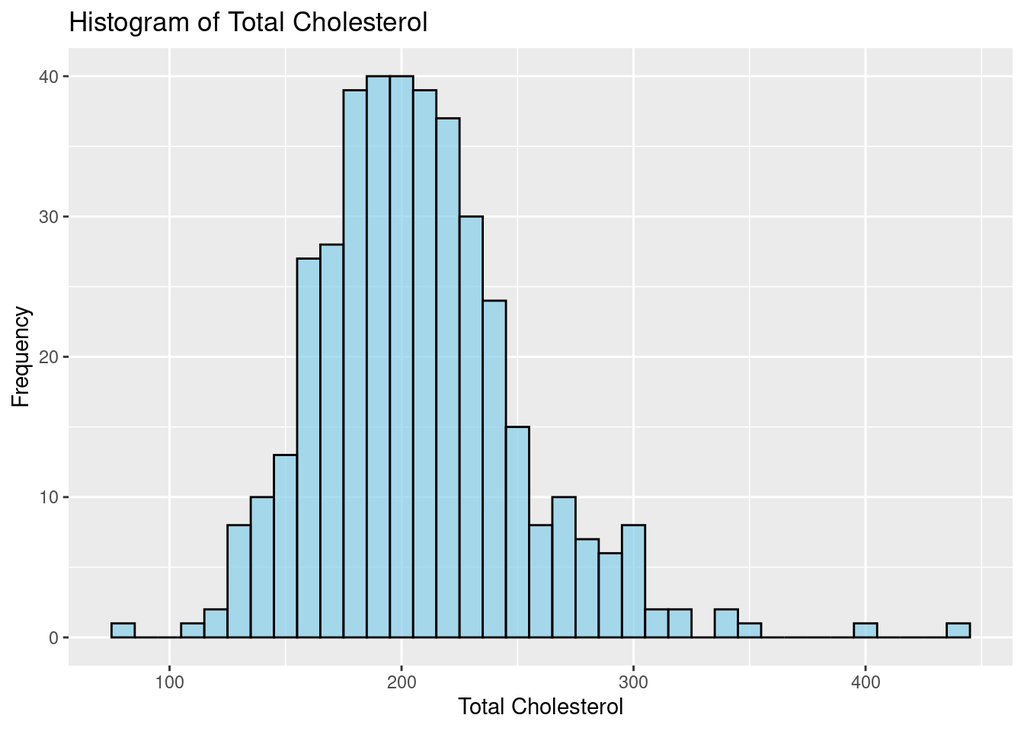

```r
ggplot(df, aes(x = total_cholesterol)) +
  geom_histogram(binwidth = 10, fill = "skyblue", color = "black", alpha = 0.7) +
  labs(title = "Histogram of Total Cholesterol",
       x = "Total Cholesterol",
       y = "Frequency")
```

**Histogram of Stabilized Glucose**

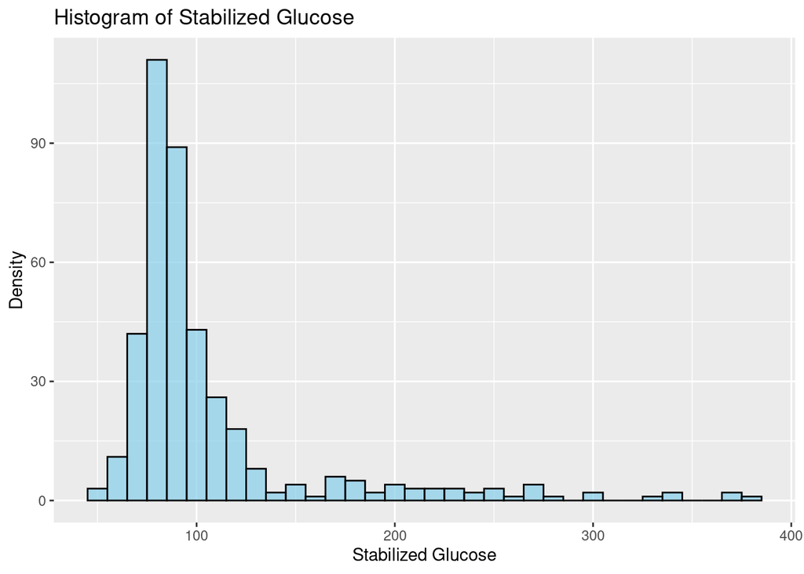

```r
ggplot(df, aes(x = stabilized.glucose)) +
  geom_histogram(binwidth = 10, fill = "skyblue", color = "black", alpha = 0.7) +
  labs(title = "Histogram of Stabilized Glucose",
       x = "Stabilized Glucose",
       y = "Density")
```

**Bar Chart of Location**

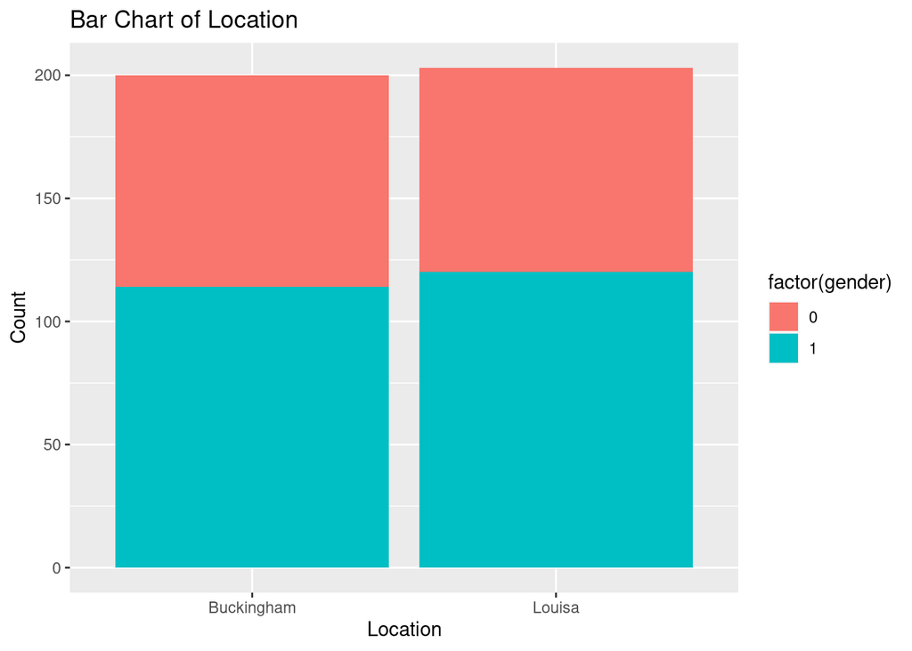

```r
ggplot(df, aes(x = location, fill = factor(gender))) +
  geom_bar() +
  labs(title = "Bar Chart of Location",
       x = "Location",
       y = "Count")
```

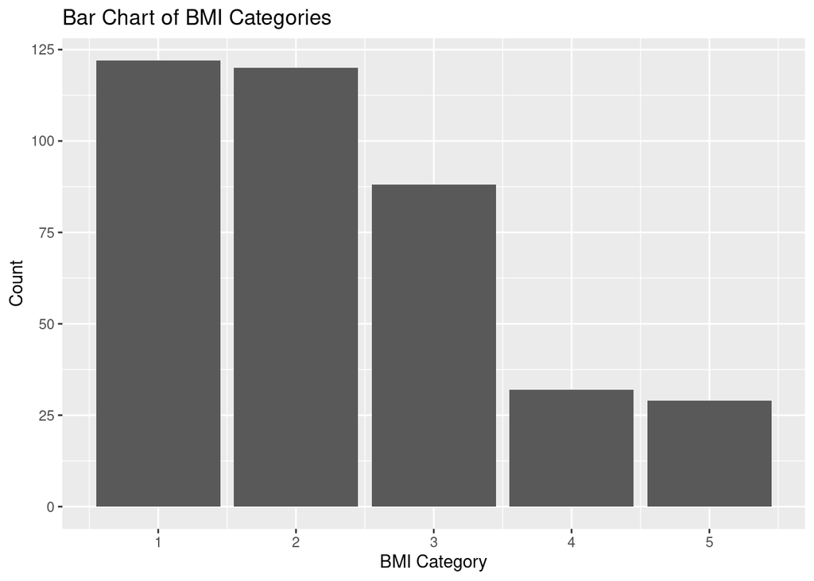

```r
ggplot(df, aes(x = BMI_cat_5, fill = BMI_cat_5)) +
  geom_bar() +
  labs(title = "Bar Chart of BMI Categories",
       x = "BMI Category",
       y = "Count")
```

## Check for outliers via 2 plots of Boxplots

**Plot1: Boxplots for each numeric variable, with geom.jitter**

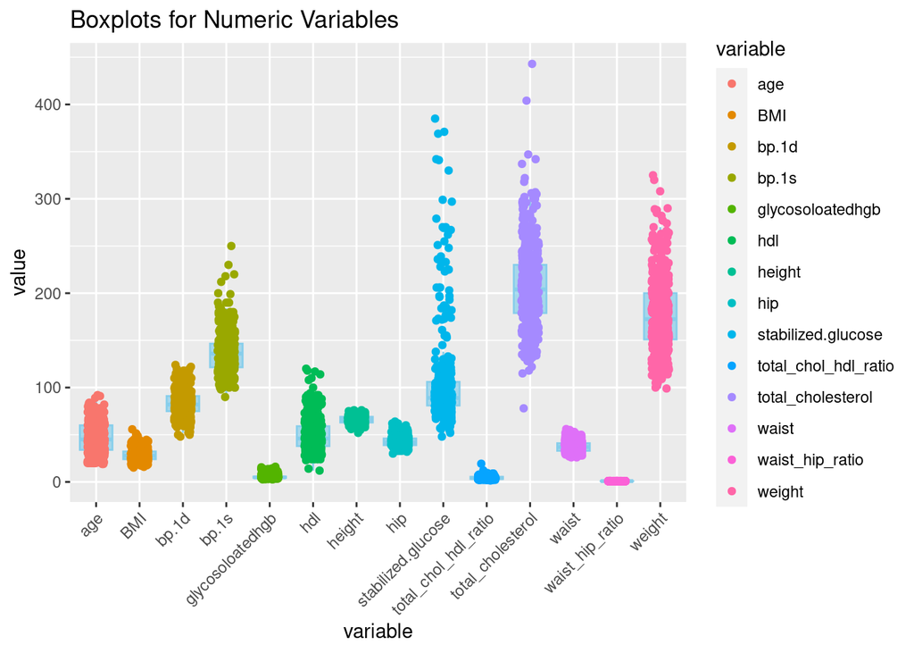

```r
selected_vars <- c("total_cholesterol", "stabilized.glucose", "hdl", "total_chol_hdl_ratio", "glycosoloatedhgb", "age" ,"height", "weight" , "bp.1s", "bp.1d" , "waist", "hip" , "BMI", "waist_hip_ratio")
df_numeric <- df[selected_vars]

df_long <- gather(df_numeric, key = "variable", value = "value")

ggplot(df_long, aes(x = variable, y = value)) +
  geom_boxplot(outlier.shape = NA, color = "skyblue", fill = "skyblue", alpha = 0.7) +
  geom_jitter(aes(color = variable), width = 0.2) +
  labs(title = "Boxplots for Numeric Variables") +
  theme(axis.text.x = element_text(angle = 45, hjust = 1))
```

The plot shows that some variables have a large variance. Because the scale is different for each variable, we also present a plot with common boxplots and logarithmic values of the variables.

**Plot 2: Boxplots for Log-Transformed Numeric Variables**

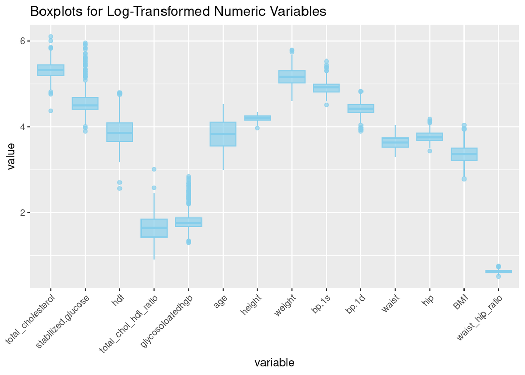

```r
df_log <- log1p(df_numeric)
df_long<-melt(df_log)
ggplot(df_long, aes(x = variable, y = value)) +
  geom_boxplot(color = "skyblue", fill = "skyblue", alpha = 0.7) +
  labs(title = "Boxplots for Log-Transformed Numeric Variables") +
  theme(axis.text.x = element_text(angle = 45, hjust = 1))
```

The second log plot clearly shows the outliers of the variables. For example, they are also observed in the variable glycosoloatedghb.

**Scatterplot for glycosoloatedghb**

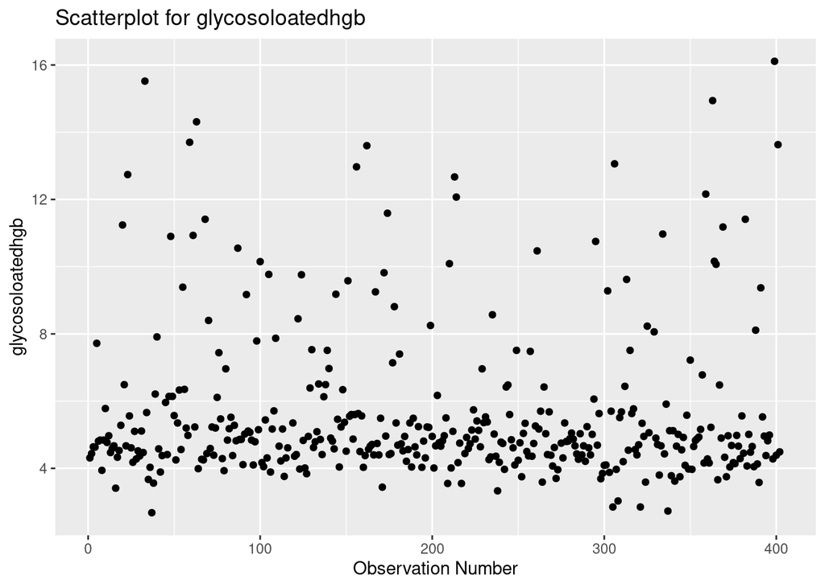

```r
ggplot(df, aes(x = 1:nrow(df), y = glycosoloatedhgb)) +
  geom_point() +
  labs(title = "Scatterplot for glycosoloatedhgb", x = "Observation Number", y = "glycosoloatedhgb")
```

**Scatterplot for stabilized.glucose**

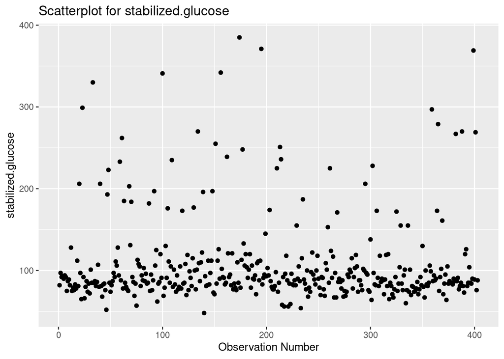

```r
ggplot(df, aes(x = 1:nrow(df), y = stabilized.glucose)) +
  geom_point() +
  labs(title = "Scatterplot for stabilized.glucose", x = "Observation Number", y = "stabilized.glucose")
```

In both cases, there are some outliers, but they are not necessarily errors. For example, for the variable stabilized.glucose, the following values are considered outliers:

**Create a scatterplot for stabilized.glucose with outliers highlighted**

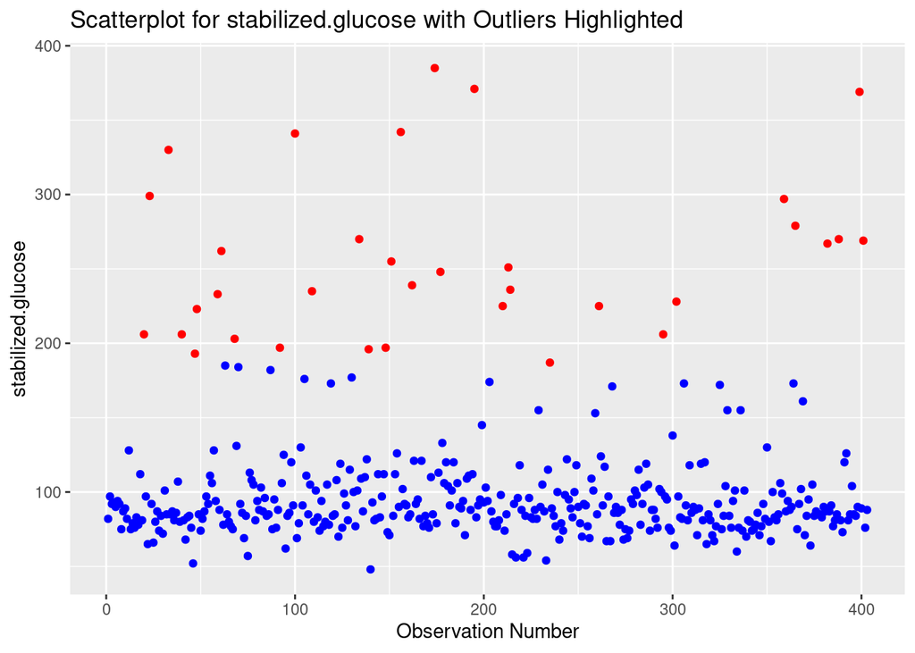

```r
threshold <- 1.5 * sd(df$stabilized.glucose)

# Identify outliers
outliers <- which(df$stabilized.glucose > mean(df$stabilized.glucose) + threshold |
                    df$stabilized.glucose < mean(df$stabilized.glucose) - threshold)


ggplot(df, aes(x = 1:nrow(df), y = stabilized.glucose)) +
  geom_point(color = ifelse(1:nrow(df) %in% outliers, "red", "blue")) +  # Color outliers in red, others in blue
  labs(title = "Scatterplot for stabilized.glucose with Outliers Highlighted", x = "Observation Number", y = "stabilized.glucose")
```

The previous code segment helps identify outliers in the stabilized.glucose variable by considering values that are significantly higher or lower than the mean, with the threshold being determined by 1.5 times the standard deviation. Outliers are those data points that fall outside this range.

In general, extreme values or potential outliers will not be deleted, as their removal could impact the data analysis

## Data Analysis

**Correlation Matrices beetwin all numeric values**

```r
library(GGally)
```

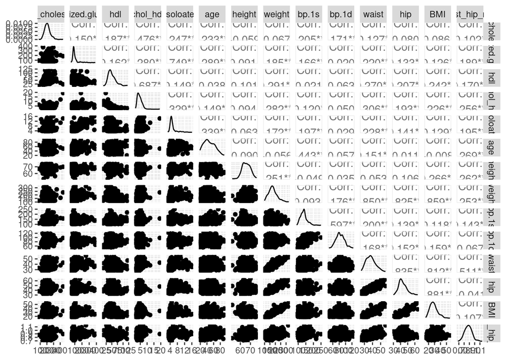

```r
ggpairs(df_numeric)
```

The correlations are mostly expected, as their variables are actually related. Some variables are calculated from other ones also. So lets plot 1 scatter plots just to understand their correlation coefficient.

**Scatter Plot and of waist and wight**

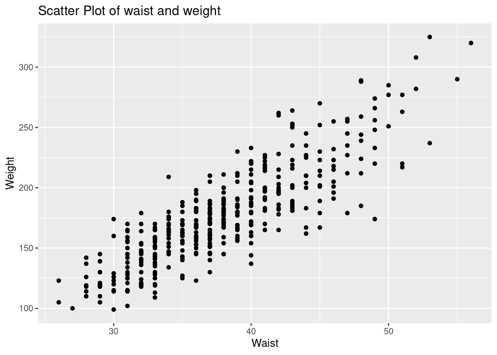

```r
ggplot(df, aes(x = waist, y = weight)) +
  geom_point() +
  labs(title = "Scatter Plot of waist and weight",
       x = "Waist",
       y = "Weight")
```

From the previous ggpairs an outlier value in the fourth variable (total_chol_hdl_ratio) is worth our attention and further investigation.

[figure not shown]

```r
# Convert diabetes_diagnosis to a factor for categorical color
df$diabetes_diagnosis <- factor(df$diabetes_diagnosis, levels = c(0, 1), labels = c("No Diabetes", "Diabetes"))

ggplot(df, aes(x = total_chol_hdl_ratio, y = weight, color = diabetes_diagnosis)) +
  geom_point() +
  labs(title = "Scatter Plot of total_chol_hdl_ratio and BMI",
       x = "Total Cholesterol to HDL Ratio",
       y = "BMI",
       color = "Diabetes Diagnosis")
```

This is an extreme value that is far from the average and will be excluded from the analysis so lets take a look with diferrent x-value(glycosoloatedhgb) and depending on gender, .

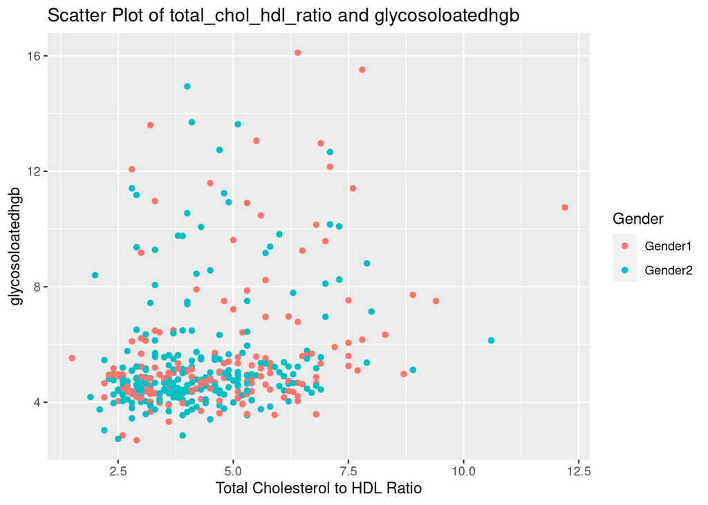

```r
df <- df %>% filter(total_chol_hdl_ratio <= 15)

# Convert gender to a factor for categorical color
df$gender <- factor(df$gender, levels = c(0, 1), labels = c("Gender1", "Gender2"))


ggplot(df, aes(x = total_chol_hdl_ratio, y = glycosoloatedhgb, color = gender)) +
  geom_point() +
  labs(title = "Scatter Plot of total_chol_hdl_ratio and glycosoloatedhgb",
       x = "Total Cholesterol to HDL Ratio",
       y = "glycosoloatedhgb",
       color = "Gender")
```

### Linear Regression

Now lets involve in our scatter plots the linear regression

[figure not shown]

```r
ggplot(df, aes(x = weight, y = hdl)) +
  geom_point() +
  geom_smooth(method = "lm", se = FALSE, linetype = "solid") +
  labs(title = "Scatter Plot of waist and hdl",
       x = "Waist",
       y = "Hdl")
```

This conclusion is consistent with existing literature. Studies have shown that obesity and overweight are associated with lower levels of HDL cholesterol.

### Height and weight

Let’s now examine the anthropometric variables weight and height in relation to some categorical variables.

**Scatter Plot of Height and Weight by Location**

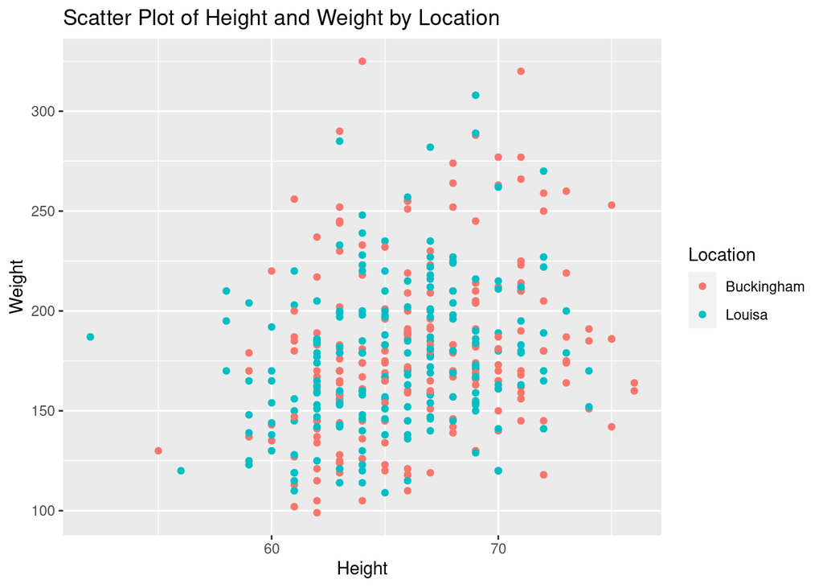

```r
ggplot(df, aes(x = height, y = weight, color = location)) +
  geom_point() +
  labs(title = "Scatter Plot of Height and Weight by Location",
       x = "Height",
       y = "Weight",
       color = "Location")
```

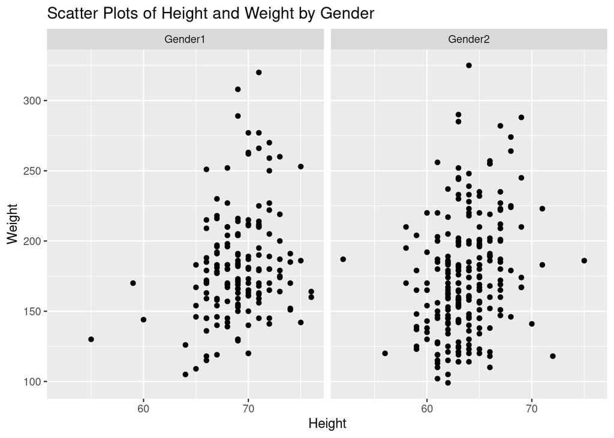

```r
ggplot(df, aes(x = height, y = weight)) +
  geom_point() +
  facet_wrap(~gender) +
  labs(title = "Scatter Plots of Height and Weight by Gender",
       x = "Height",
       y = "Weight")
```

From the previous graph, it is inferred that that gender1 refers to man, but thats something we dont really care of.

### Diabetes Diagnosis

The remaining plots pertain to the variable “diabetes diagnosis.”

**Distribution of Diabetes Diagnosis**

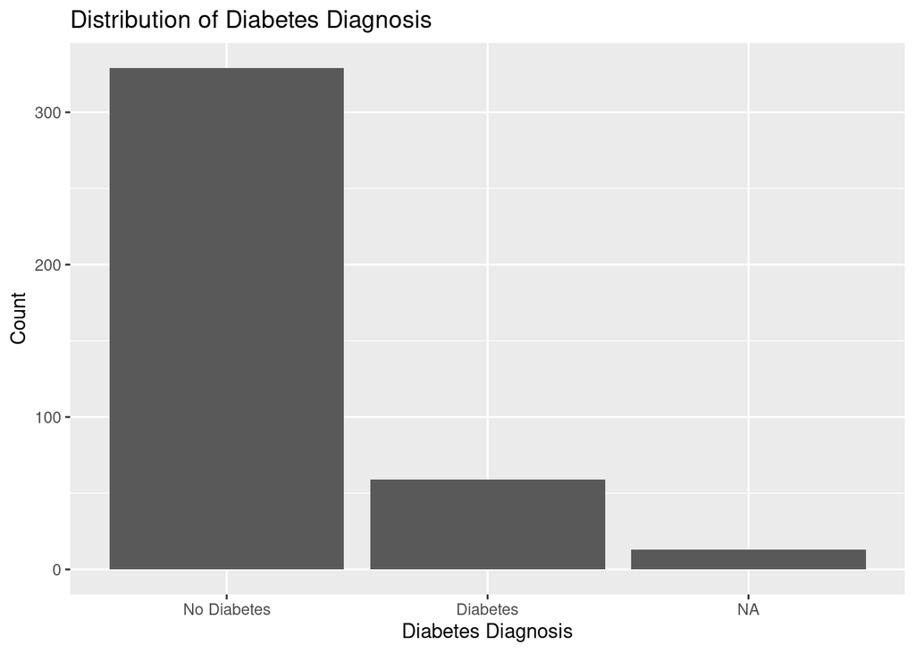

```r
ggplot(df, aes(x = factor(diabetes_diagnosis))) +
  geom_bar() +
  labs(title = "Distribution of Diabetes Diagnosis",
       x = "Diabetes Diagnosis",
       y = "Count")
```

**Box Plot of Stabilized Glucose by Diabetes Diagnosis**

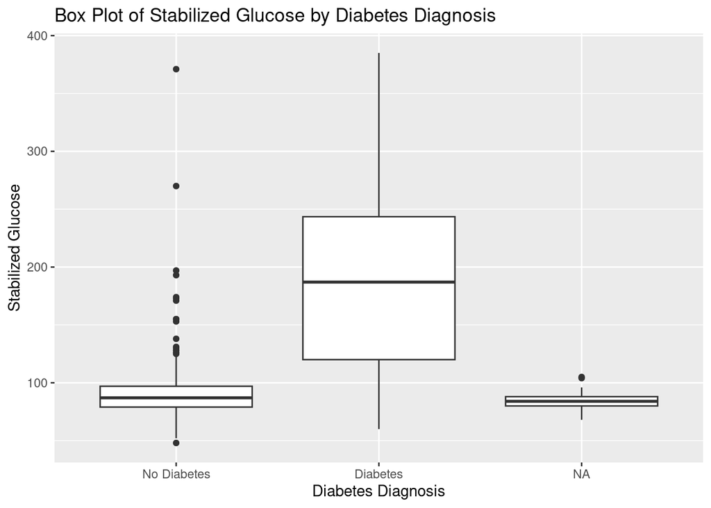

```r
ggplot(df, aes(x = factor(diabetes_diagnosis), y = stabilized.glucose)) +
  geom_boxplot() +
  labs(title = "Box Plot of Stabilized Glucose by Diabetes Diagnosis",
       x = "Diabetes Diagnosis",
       y = "Stabilized Glucose")
```

The reason for creating this plot is to demonstrate that, on average, a high value in Stabilized Glucose leads to diabetes, but there are also some exceptions.

Now, let’s see if gender affects the above conclusion.

**Box Plot of Stabilized Glucose by Diabetes Diagnosis by Gender**

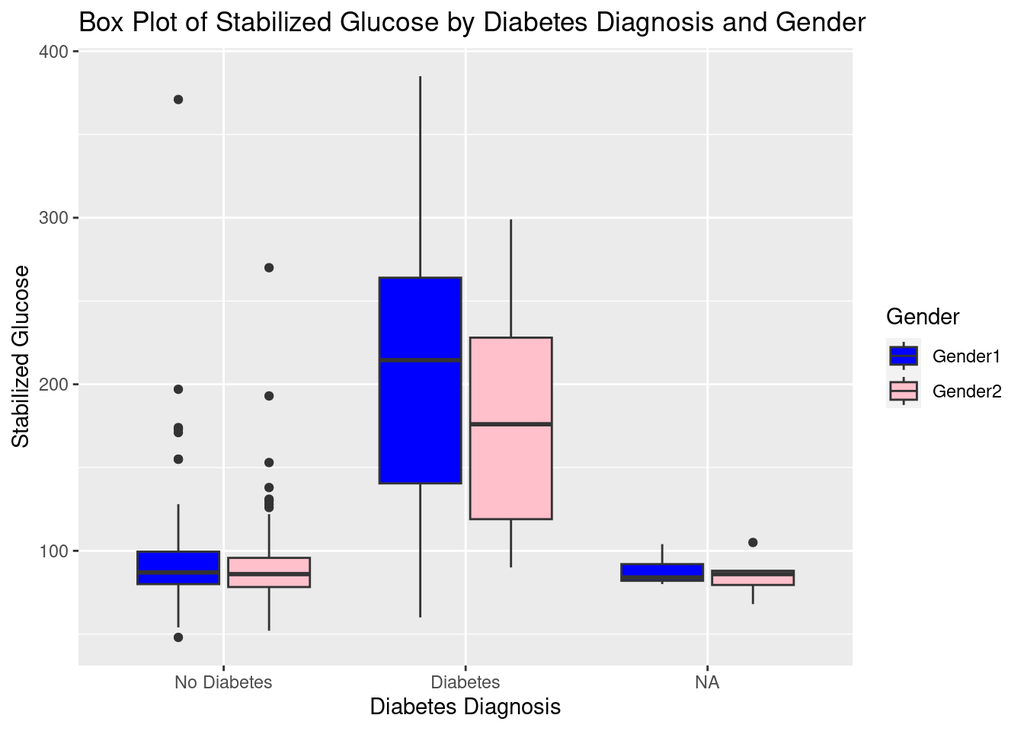

```r
ggplot(df, aes(x = factor(diabetes_diagnosis), y = stabilized.glucose, fill = factor(gender))) +
  geom_boxplot() +
  labs(title = "Box Plot of Stabilized Glucose by Diabetes Diagnosis and Gender",
       x = "Diabetes Diagnosis",
       y = "Stabilized Glucose",
       fill = "Gender") +
  scale_fill_manual(values = c("blue", "pink"))
```

Now, let’s add the variable “Location” to the above plot.

**Box Plot of Stabilized Glucose by Diabetes Diagnosis, Gender, and Location**

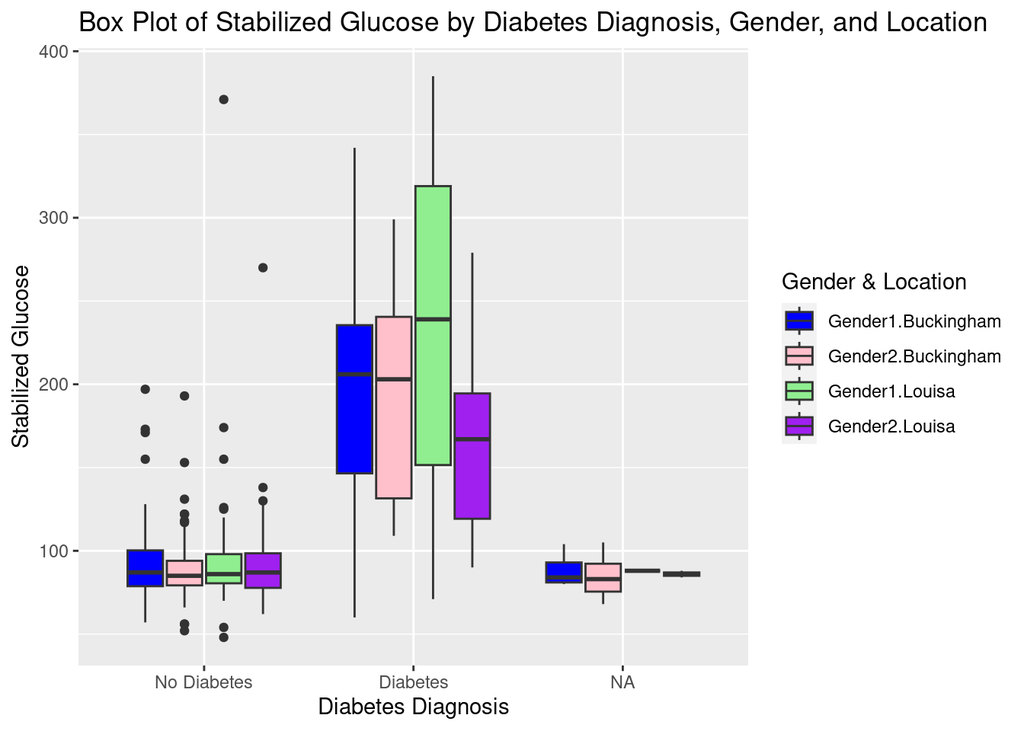

```r
ggplot(df, aes(x = factor(diabetes_diagnosis), y = stabilized.glucose, fill = interaction(factor(gender), location))) +
  geom_boxplot() +
  labs(title = "Box Plot of Stabilized Glucose by Diabetes Diagnosis, Gender, and Location",
       x = "Diabetes Diagnosis",
       y = "Stabilized Glucose",
       fill = "Gender & Location") +
  scale_fill_manual(values = c("blue", "pink", "lightgreen", "purple", "orange", "brown"))
```

### Catergorical Variables

So far, we have seen plots related to numeric variables or numeric variables with a categorical one or a combination of them. Let’s now explore plots involving categorical variables. Let’s plot first a plot based on diabetes_diagnosis

**Bar Plot of Gender and Diabetes Diagnosis**

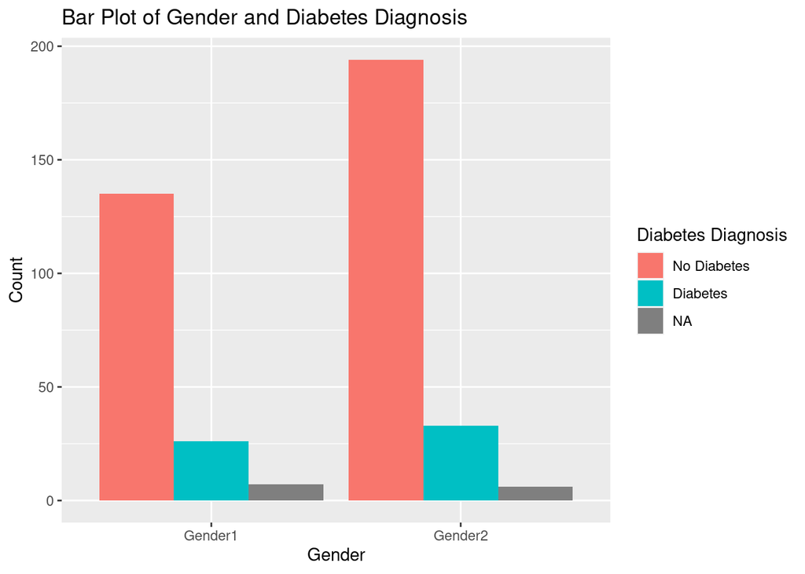

```r
df$gender <- factor(df$gender)
df$diabetes_diagnosis <- factor(df$diabetes_diagnosis)

# Δημιουργία του bar plot
ggplot(df, aes(x = gender, fill = diabetes_diagnosis)) +
  geom_bar(position = "dodge", stat = "count") +
  labs(title = "Bar Plot of Gender and Diabetes Diagnosis",
       x = "Gender",
       y = "Count",
       fill = "Diabetes Diagnosis")
```

**Bar Plot of Age Category and BMI Category**

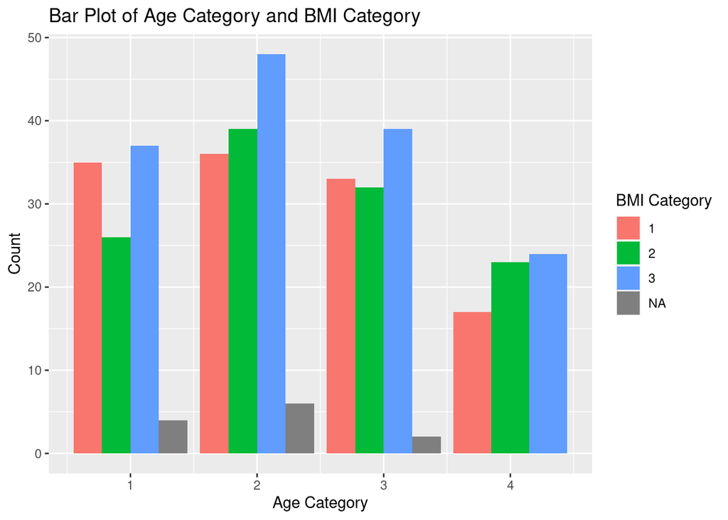

```r
df$BMI_cat_3 <- factor(df$BMI_cat_3)


ggplot(df, aes(x = age_cat, fill = BMI_cat_3)) +
  geom_bar(position = "dodge", stat = "count") +
  labs(title = "Bar Plot of Age Category and BMI Category",
       x = "Age Category",
       y = "Count",
       fill = "BMI Category")
```

Let’s add a third categorical variable as well.

**Bar Plot of Age Category and BMI Category (Colored by Gender)**

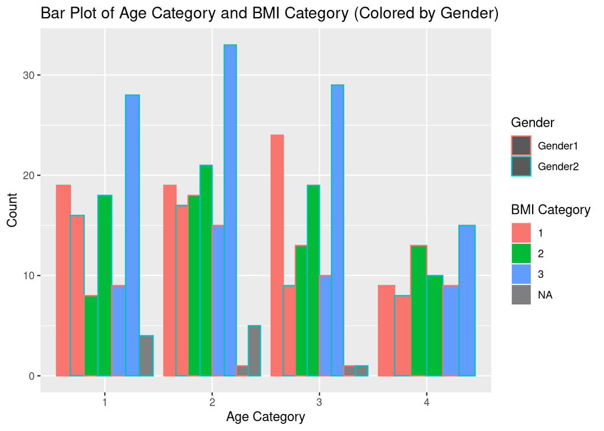

```r
df$BMI_cat_3 <- factor(df$BMI_cat_3)
df$age_cat <- factor(df$age_cat)
df$gender <- factor(df$gender)

# Δημιουργία του bar plot με χρήση χρώματος για το gender
ggplot(df, aes(x = age_cat, fill = BMI_cat_3, color = gender)) +
  geom_bar(position = "dodge", stat = "count") +
  labs(title = "Bar Plot of Age Category and BMI Category (Colored by Gender)",
       x = "Age Category",
       y = "Count",
       fill = "BMI Category",
       color = "Gender")
```

Another way to visualize two categorical variables is through heatmaps.

**Heatmap of Location and Diabetes Diagnosis**

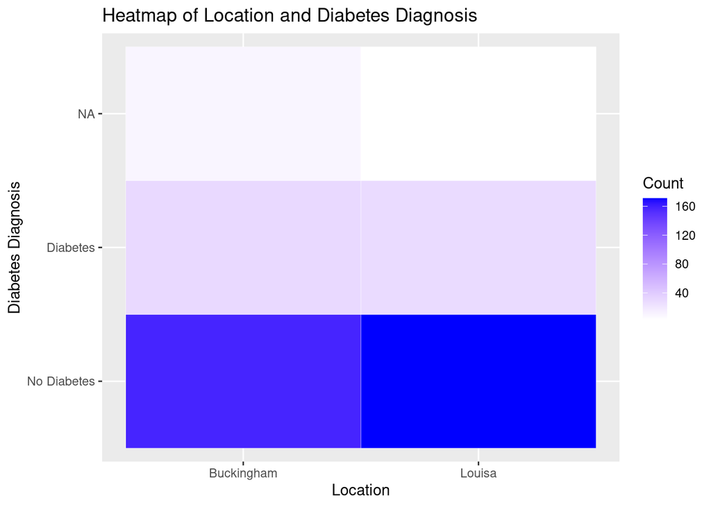

```r
df$location <- factor(df$location)
df$diabetes_diagnosis <- factor(df$diabetes_diagnosis)

ggplot(df, aes(x = location, y = diabetes_diagnosis)) +
  geom_bin2d(aes(fill = stat(count)), color = "white") +
  scale_fill_gradient(low = "white", high = "blue") +
  labs(title = "Heatmap of Location and Diabetes Diagnosis",
       x = "Location",
       y = "Diabetes Diagnosis",
       fill = "Count")
```

**Heatmap of BMI_cat5 and Age_cat**

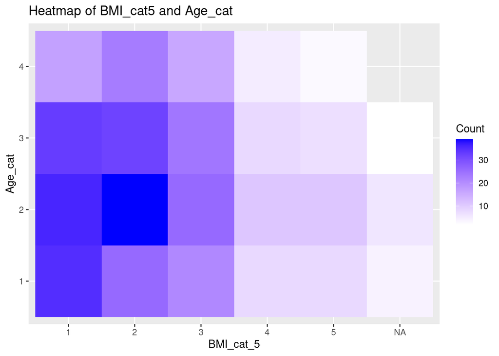

```r
df$BMI_cat_5 <- factor(df$BMI_cat_5)

ggplot(df, aes(x = BMI_cat_5, y = age_cat, fill = ..count..)) +
  geom_bin2d() +
  scale_fill_gradient(low = "white", high = "blue") +
  labs(title = "Heatmap of BMI_cat5 and Age_cat",
       x = "BMI_cat_5",
       y = "Age_cat",
       fill = "Count")
```

**Heatmap of 3 Variables**

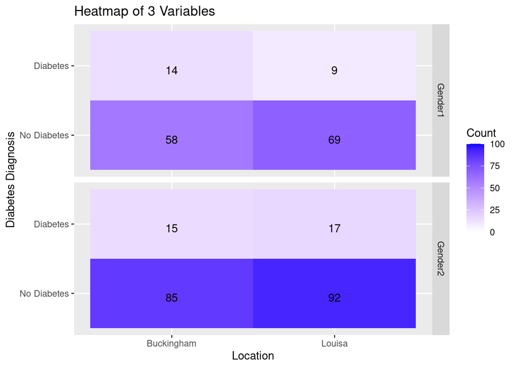

```r
subset_df<-df
subset_df$location <- factor(df$location)
subset_df$diabetes_diagnosis <- factor(df$diabetes_diagnosis)
subset_df$gender <- factor(df$gender)

# Αφαίρεση των γραμμών που περιέχουν NA
subset_df <- na.omit(subset_df)

ggplot(subset_df, aes(x = location, y = diabetes_diagnosis, fill = ..count..)) +
  geom_bin2d() +
  geom_text(aes(label = ..count..), stat = "bin2d", vjust = 1, color = "black") +
  scale_fill_gradient(low = "white", high = "blue", limits = c(0, 100)) +
  facet_grid(gender ~ .) +
  labs(title = "Heatmap of 3 Variables",
       x = "Location",
       y = "Diabetes Diagnosis",
       fill = "Count")
```

In the following diagram, we have a plot involving 4 variables. On the right, we have BMI_cat_5, and at the top, the division based on age_cat.

**Heatmap of Multiple Variables**

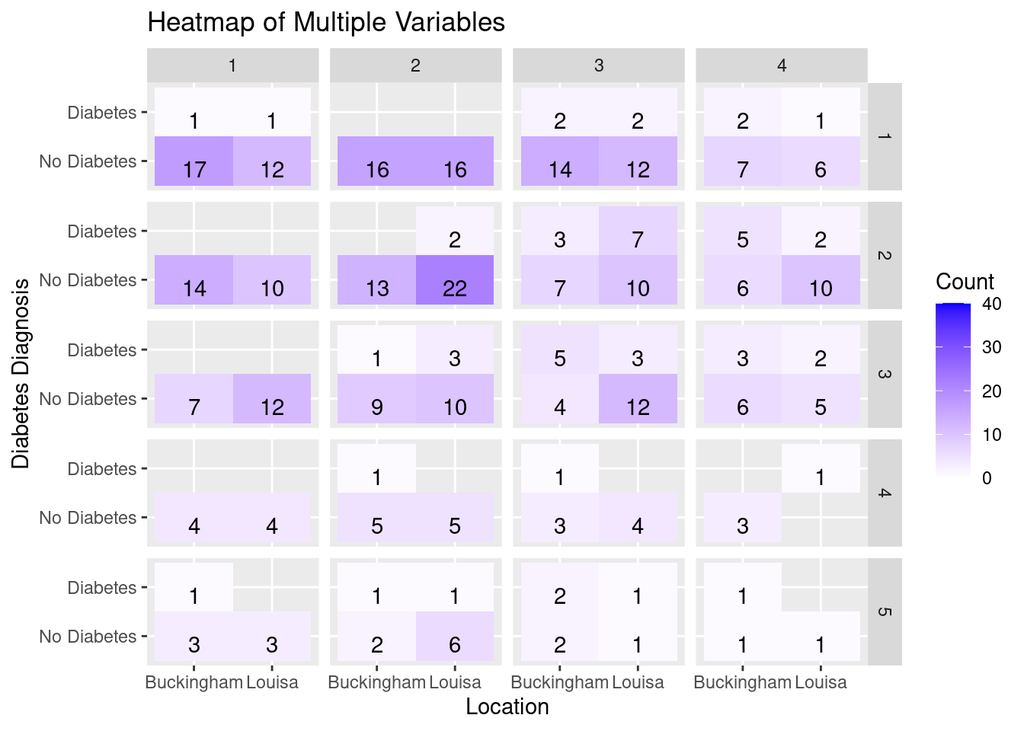

```r
subset_df<-df
subset_df$location <- factor(df$location)
subset_df$diabetes_diagnosis <- factor(df$diabetes_diagnosis)
subset_df$BMI_cat_5 <- factor(df$BMI_cat_5)
subset_df$age_cat <- factor(df$age_cat)

# Αφαίρεση των γραμμών που περιέχουν NA
subset_df <- na.omit(subset_df)

ggplot(subset_df, aes(x = location, y = diabetes_diagnosis, fill = ..count..)) +
  geom_bin2d() +
  geom_text(aes(label = ..count..), stat = "bin2d", vjust = 1, color = "black") +
  scale_fill_gradient(low = "white", high = "blue", limits = c(0, 40)) +
  facet_grid(BMI_cat_5 ~ age_cat) +
  labs(title = "Heatmap of Multiple Variables",
       x = "Location",
       y = "Diabetes Diagnosis",
       fill = "Count")
```

Therefore, in the data analysis presented, visualization methods for a single variable, combinations of numeric variables, and combinations of categorical with numeric variables were demonstrated. In the end, there are visualizations involving interactions between categorical variables, with the heatmap being the most efficient.

# Part B

Now, a subset of the previous dataset is provided, containing many missing values that need to be addressed. In the end, a comparison will be made with the original dataset to evaluate the imputation.

## Underestanding the Dataset

```r
df2 <- read.csv("diabetes2.csv")
df <- read.csv("diabetes.csv")
head(df2)
```

```
##   total_cholesterol age gender weight
## 1               203  46     NA    121
## 2               165  NA      1     NA
## 3                NA  NA      1    256
## 4                NA  67      0     NA
## 5               249  64      0    183
## 6                NA  34      0    190
```

```r
print(colSums(is.na(df2)))
```

```
## total_cholesterol               age            gender            weight
##               114               135               122               114
```

## Impute Missing Values

The “mice” package provides functions for creating imputed datasets and replacing missing values. The Random Forest method (method = “rf”) is used to predict the missing values of “age” and “total_cholesterol”. The parameters m = 5 determine the number of samples to be created, and maxit = 50 determines the number of iterations.

```r
# Φορτώστε τη βιβλιοθήκη caret
library(mice)

# Δημιουργία ενός διαμερισματοποιημένου dataset με τις απουσιάζουσες τιμές στο "age"
imputed_data <- mice(df2[, c("total_cholesterol", "gender", "weight", "age")],
                      method = "rf", # Χρησιμοποιούμε τη μέθοδο Random Forest για την πρόβλεψη του "age"
                      m = 5,           # Αριθμός δειγμάτων που θα δημιουργηθούν
                      maxit = 50)      # Αριθμός επαναλήψεων
# Συμπληρώστε τις απουσιάζουσες τιμές στο αρχικό dataset
df2$age <- complete(imputed_data)$age
df2$total_cholesterol <- complete(imputed_data)$total_cholesterol
```

```r
imputed_weight_data <- mice(df2[, c("total_cholesterol", "gender", "age", "weight")],
                             method = "pmm", # Χρησιμοποιούμε τη μέθοδο PMM
                             m = 5,           # Αριθμός δειγμάτων που θα δημιουργηθούν
                             maxit = 50)      # Αριθμός επαναλήψεων
# Συμπλήρωση των απουσιάζουσων τιμών στο αρχικό dataset
df2$weight <- complete(imputed_weight_data)$weight
df2$gender <- complete(imputed_data)$gender
```

## Prediction Evaluation

### For categorical Variable

```r
result_text <- paste0("Το άθροισμα της μεταβλητής gender για το Actual όταν η τιμή της είναι 0 είναι: ", sum(df$gender == 0))
print(result_text)
```

```
## [1] "Το άθροισμα της μεταβλητής gender για το Actual όταν η τιμή της είναι 0 είναι: 169"
```

```r
result_text <- paste0("Το άθροισμα της μεταβλητής gender για το Predicted όταν η τιμή της είναι 0 είναι: ", sum(df2$gender == 0))
print(result_text)
```

```
## [1] "Το άθροισμα της μεταβλητής gender για το Predicted όταν η τιμή της είναι 0 είναι: 155"
```

```r
result_text <- paste0("Το άθροισμα της μεταβλητής gender για το Actual όταν η τιμή της είναι 1 είναι: ", sum(df$gender == 1))
print(result_text)
```

```
## [1] "Το άθροισμα της μεταβλητής gender για το Actual όταν η τιμή της είναι 1 είναι: 234"
```

```r
result_text <- paste0("Το άθροισμα της μεταβλητής gender για το Predicted όταν η τιμή της είναι 1 είναι: ", sum(df2$gender == 1))
print(result_text)
```

```
## [1] "Το άθροισμα της μεταβλητής gender για το Predicted όταν η τιμή της είναι 1 είναι: 248"
```

### For numeric variables

**total_cholesterol**

```r
result_text <- paste0("O μέσος όρος μεταβλητής total_cholesterol για το Αctual είναι: ", mean(df$total_cholesterol, na.rm = TRUE))
print(result_text)
```

```
## [1] "O μέσος όρος μεταβλητής total_cholesterol για το Αctual είναι: 207.845771144279"
```

```r
result_text <- paste0("O μέσος όρος μεταβλητής total_cholesterol για το Predicted είναι: ", mean(df2$total_cholesterol, na.rm = TRUE))
print(result_text)
```

```
## [1] "O μέσος όρος μεταβλητής total_cholesterol για το Predicted είναι: 209.344913151365"
```

**weight**

```r
result_text <- paste0("O μέσος όρος μεταβλητής weight για το Αctual είναι: ", mean(df$weight, na.rm = TRUE))
print(result_text)
```

```
## [1] "O μέσος όρος μεταβλητής weight για το Αctual είναι: 177.592039800995"
```

```r
result_text <- paste0("O μέσος όρος μεταβλητής weight για το Predicted όταν  είναι: ", mean(df2$weight, na.rm = TRUE))
print(result_text)
```

```
## [1] "O μέσος όρος μεταβλητής weight για το Predicted όταν  είναι: 178.707196029777"
```

**age**

```r
result_text <- paste0("O μέσος όρος μεταβλητής age για το Αctual είναι: ", mean(df$age, na.rm = TRUE))
print(result_text)
```

```
## [1] "O μέσος όρος μεταβλητής age για το Αctual είναι: 46.8511166253102"
```

```r
result_text <- paste0("O μέσος όρος μεταβλητής age για το Predicted όταν  είναι: ", mean(df2$age, na.rm = TRUE))
print(result_text)
```

```
## [1] "O μέσος όρος μεταβλητής age για το Predicted όταν  είναι: 47.1885856079404"
```

Γενικά τα αποτελέσματα είναι πολύ κοντά στις πραγματικές τιμές, τα μοντέλα απέδωσαν.